# A Dataset for Assessing Worker Activities in Industrial Settings

## Overview and Motivation

Industrial Internet of Things (IIoT) solutions can improve manufacturing efficiency by monitoring machine and human performance. This dataset was collected to support real-time activity recognition of meat-processing workers, thereby enabling computation of fine-grained KPIs such as idle time and throughput.

This dataset accompanies the paper “An Industrial IoT Solution for Evaluating Workers’ Performance via Activity Recognition.” It contains sensor data from wearable accelerometers and gyroscopes, recorded in a meat-processing plant. The data are labeled by experts according to seven distinct activities (e.g., waiting, slicing, cutting, etc.), allowing for applications in Human Activity Recognition in industrial settings.

Research Paper Link: https://doi.org/10.1109/icdcs.2019.00139

## Key Data Characteristics

- **Wearable Sensor Data**: Accelerometer and gyroscope readings from workers’ wrists (both hands).
- **Rich Annotations**: Labeled per-second activities, including waiting, slicing, cutting, pulling, reaching, feeling.
- **Collected in Real World Environment**: Recorded in real production shifts in a meat processing plant.
- **Preliminary Models**: Models provided for recognising and classifying worker activities.

## Description of Data Collection Mechanism

[figure not shown]

Figure 1: The distributed architecture of the proposed IIoT solution for worker identification and activity recognition.

The data was collected through the architecture described in Figure 1.

[figure not shown]

Figure 2: MetaWear sensor worn on both hands (left) and worn while working (right)

Data from the sensors was transmitted via BLE (Bluetooth Low Energy) to Raspberry Pi devices installed underneath the workers’ benches, as shown in Figure 3. These edge devices were waterproof, battery-powered, and designed to function within hygiene and safety constraints of an industrial setting. The Raspberry Pi devices then forwarded the data to a central cloud server for activity learning.

[figure not shown]

Figure 3: Raspberry Pi in Packages (left) and Raspberry Pi Placement (Circled in Red) on Workbench (right)

## Description of the Feature Engineered Dataset

The MetaWear sensors collected the acceleration and gyroscope data from the x, y, and z-axes. From this raw data, 156 features were derived (see Feature Derivation Section).

In order to capture the ground truth in a non-intrusive fashion, worker activity was captured using a high-resolution video camera. A domain expert watched the video and labelled the activities performed, which were synchronised with the collected data using the timestamps. A total of ~45 minutes of annotated data per worker was collected for four workers.

The activities labelled can be characterised as follows:

| Activity | Label | Description | Observation |
| --- | --- | --- | --- |
| **Idle/Waiting** | 0 | The worker remains stationary, awaiting the next piece of meat to arrive for processing. | No piece of meat or knife is involved; hands remain still. |
| **Knife Sharpening** | 1 | The worker uses both hands to sharpen the cutting knife with sharpening tools. | No meat is involved; only the knife and sharpening tools are used. |
| **Slicing** | 2 | The worker trims fat from the meat using a knife. | Knife movements are primarily horizontal. |
| **Cutting** | 3 | The worker divides large portions of meat into smaller pieces using a knife. | Knife movements are mostly vertical. |
| **Pulling** | 4 | The worker tears fat away from the meat using both hands. | Primarily involves the use of both hands. |
| **Reaching** | 5 | The worker reaches out to retrieve a new piece of meat from the conveyor belt. | Mainly involves the non-cutting hand (left hand). |
| **Feeling** | 6 | The worker touches the surface of the meat piece to detect areas requiring further trimming. | Mostly involves the use of both hands. |

## Feature Description and Computation

From the sensors, 43 features were derived from acceleration and 35 for gyro for each hand. This gives a total of 2 x 43 + 2 x 35 = 156 features in total for both hands. Below is the name and description for each feature:

| Feature Name | Description |
| --- | --- |
| acc_mean_x_right | Mean value of the Accelerometer signal along the x axis for the right hand over 1 second |
| acc_mean_y_right | Mean value of the Accelerometer signal along the y axis for the right hand over 1 second |
| acc_mean_z_right | Mean value of the Accelerometer signal along the z axis for the right hand over 1 second |
| acc_mean_xyz_right | Mean value of the magnitude of the acceleration in the xyz-space for the right hand over 1 second |
| acc_mean_xy_right | Mean value of the Accelerometer signal along xy-plane for the right hand over 1 second |
| acc_mean_yz_right | Mean value of the Accelerometer signal along yz-plane for the right hand over 1 second |
| acc_mean_zx_right | Mean value of the Accelerometer signal along zx-plane for the right hand over 1 second |
| acc_mean_pitch_right | Mean value of the Accelerometer signal along the Pitch angle for the right hand over 1 second |
| acc_mean_roll_right | Mean value of the Accelerometer signal along the Roll angle for the right hand over 1 second |
| acc_std_x_right | Standard deviation of the Accelerometer signal along the x axis for the right hand over 1 second |
| acc_std_y_right | Standard deviation of the Accelerometer signal along the y axis for the right hand over 1 second |
| acc_std_z_right | Standard deviation of the Accelerometer signal along the z axis for the right hand over 1 second |
| acc_std_xyz_right | Standard deviation of the magnitude of the acceleration in the xyz-space for the right hand over 1 second |
| acc_std_xy_right | Standard deviation of the Accelerometer signal along xy-plane for the right hand over 1 second |
| acc_std_yz_right | Standard deviation of the Accelerometer signal along yz-plane for the right hand over 1 second |
| acc_std_zx_right | Standard deviation of the Accelerometer signal along zx-plane for the right hand over 1 second |
| acc_std_pitch_right | Standard deviation of the Accelerometer signal along the Pitch angle for the right hand over 1 second |
| acc_std_roll_right | Standard deviation of the Accelerometer signal along the Roll angle for the right hand over 1 second |
| acc_auc_x_right | Area under the curve of the Accelerometer signal along the x axis for the right hand over 1 second |
| acc_auc_y_right | Area under the curve of the Accelerometer signal along the y axis for the right hand over 1 second |
| acc_auc_z_right | Area under the curve of the Accelerometer signal along the z axis for the right hand over 1 second |
| acc_auc_xyz_right | Area under the curve of the magnitude of the acceleration in the xyz-space for the right hand over 1 second |
| acc_auc_xy_right | Area under the curve of the Accelerometer signal along xy-plane for the right hand over 1 second |
| acc_auc_yz_right | Area under the curve of the Accelerometer signal along yz-plane for the right hand over 1 second |
| acc_auc_zx_right | Area under the curve of the Accelerometer signal along zx-plane for the right hand over 1 second |
| acc_auc_pitch_right | Area under the curve of the Accelerometer signal along the Pitch angle for the right hand over 1 second |
| acc_auc_roll_right | Area under the curve of the Accelerometer signal along the Roll angle for the right hand over 1 second |
| acc_max_x_right | Maximum value of the Accelerometer signal along the x axis for the right hand over 1 second |
| acc_max_y_right | Maximum value of the Accelerometer signal along the y axis for the right hand over 1 second |
| acc_max_z_right | Maximum value of the Accelerometer signal along the z axis for the right hand over 1 second |

[output cut: 126 more lines]

The features were derived as follows:

Firstly, for acceleration

Let:

$a x , a y , a z$ be the acceleration components along the **x, y, and z axes**.

$a x y z = a x 2 + a y 2 + a z 2$ be the **total acceleration magnitude**.

$a x y = a x 2 + a y 2$ be the **XY-plane acceleration magnitude**.

$a x z = a x 2 + a z 2$ be the **XZ-plane acceleration magnitude**.

$a y z = a y 2 + a z 2$ be the **YZ-plane acceleration magnitude**.

$N$ is the **number of samples per second**.

$t$ represents **time**.

$D$ represents the dimension or plane of the feature (x, y, z, xy, xz, yz, xyz)

$S$ represents the **side (Right/Left)**.

Thus, features can be denoted as: Feature_D_S

For accelerations, we can use the following formulae to derive the features:

**Mean**

$acc_mean_D_S = 1 N ∑ i = 1 N a D ( i )$

Where $i$ represents the index of an acceleration sample over a second.

**Standard deviation**

$acc_std_D_S = 1 N ∑ i = 1 N ( a D (i) − μ D ) 2$

Where $μ D$ is acc_mean_D_S

**Area Under Curve**

$acc_auc_D_S = ∑ i = 1 N a D (i) ⋅ Δ t$

**Max**

$acc_max_D_S = max ( a D (i) )$

**Peak**

This counts the number of peaks in the second.

$acc_peak_D_S = ∑ i = 2 N - 1 𝔹 ( a D ( i ) > a D ( i − 1 ) ∧ a D ( i ) > a D ( i + 1 ) )$

Where $𝔹$ is a Boolean indicator function that returns 1 when true and 0 when false.

We can derive the gyro features as follows.

Let:

$g x , g y , g z$ be the angular velocity components along the **x, y, and z axes**.

$g x y z = g x 2 + g y 2 + g z 2$ be the **total angular velocity magnitude**.

$g x y = g x 2 + g y 2$ be the **XY-plane angular velocity magnitude**.

$g x z = g x 2 + g z 2$ be the **XZ-plane angular velocity magnitude**.

$g y z = g y 2 + g z 2$ be the **YZ-plane angular velocity magnitude**.

$N$ is the **number of samples per second**.

$t$ represents **time**.

$D$ represents the dimension or plane of the feature (x, y, z, xy, xz, yz, xyz)

$S$ represents the **side (Right/Left)**.

For gyroscope data, the following formulae can be used to derive the features:

**Mean**

$gyro_mean_D_S = 1 N ∑ i = 1 N g D ( i )$

**Standard deviation**

$gyro_std_D_S = 1 N ∑ i = 1 N ( g D (i) − μ D ) 2$

Where $μ D$ is gyro_mean_D_S

**Area Under Curve**

$gyro_auc_D_S = ∑ i = 1 N g D (i) ⋅ Δ t$

**Max**

$gyro_max_D_S = max ( g D (i) )$

**Peak**

This counts the number of peaks in the second.

$gyro_peak_D_S = ∑ i = 2 N - 1 𝔹 ( g D ( i ) > g D ( i − 1 ) ∧ g D ( i ) > g D ( i + 1 ) )$

Where $𝔹$ is a Boolean indicator function that returns 1 when true and 0 when false.

## Data Download

### Direct Downloads:

[[Download Class 3 Dataset CSV File]](https://github.com/DigitalInnovationLab/mpp_dataset/blob/main/feature-engineered-data/class-3-dataset.csv)

[[Download Class 7 Dataset CSV File]](https://github.com/DigitalInnovationLab/mpp_dataset/blob/main/feature-engineered-data/class-7-dataset.csv)

### GitHub Repository:

[git clone https://github.com/DigitalInnovationLab/mpp_dataset.git](https://github.com/DigitalInnovationLab/mpp_dataset.git)

# **Deep Dive into Classifiers**

This Notebook provides a structured breakdown of the classifiers.

For both 3 and 7 classes, we use the same approach, only that the data imported is different.

This overview includes:

- **Importing dependencies**
- **Exploring the dataset**
- **Data preprocessing steps**
- **Training and evaluating models**

## **1. Importing Dependencies**

This section imports all required libraries for data manipulation, machine learning, and evaluation.

```python
import pandas as pd
import numpy as np
import matplotlib.pyplot as plt
import seaborn as sns

from sklearn.model_selection import train_test_split, GridSearchCV
from sklearn.preprocessing import StandardScaler
from sklearn.decomposition import PCA
from imblearn.over_sampling import SMOTE

from sklearn.linear_model import LogisticRegression
from sklearn.tree import DecisionTreeClassifier
from sklearn.ensemble import RandomForestClassifier
from sklearn.neighbors import KNeighborsClassifier
from sklearn.svm import SVC
from sklearn.neural_network import MLPClassifier

from sklearn.metrics import accuracy_score, f1_score, confusion_matrix, ConfusionMatrixDisplay

from IPython.display import display
```

## **2. Dataset Exploration**

### Loading Dataset

For 3-Class

```python
# Load dataset
df = pd.read_csv("class_3_dataset.csv")
```

### Preliminary Information

Class Label Meaning:

0 = waiting/idle

1 = sharpening

2 = slicing

3 = cutting

4 = pulling

5 = reaching

6 = feeling

```python
# Display dataset info
df.info()
print(df.shape)

# Define feature and label columns
X, y = df.iloc[:, :-1], df.iloc[:, -1]
```

```
<class 'pandas.core.frame.DataFrame'>
RangeIndex: 11629 entries, 0 to 11628
Columns: 157 entries, acc_mean_x_right to class
dtypes: float64(128), int64(29)
memory usage: 13.9 MB
(11629, 157)
```

### Class Distribution

It can be observed that certain classes are quite under-represented, showing how this is an imbalanced dataset.

With 3 classes, class 0 and 1 are under-represented, and with 7 classes, class 4 and 6 are under-represented.

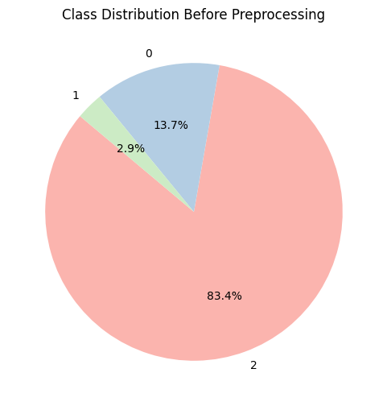

```python
# Function to plot class distribution
def plot_class_distribution(y, title):
    class_counts = y.value_counts()
    plt.figure(figsize=(6, 6))
    plt.pie(class_counts, labels=class_counts.index, autopct='%1.1f%%', startangle=140, colors=plt.cm.Pastel1.colors)
    plt.title(title)
    plt.show()

# Plot class distribution before and after SMOTE
plot_class_distribution(y, "Class Distribution Before Preprocessing")
```

### Correlation Heatmap

It can be seen that there are various features that are highly correlated with each other, making them redundant. Moreover, features can be streamlined by removing those which are not highly correlated with the class.

Note: not all feature labels are shown on the axes due to the high number of features present.

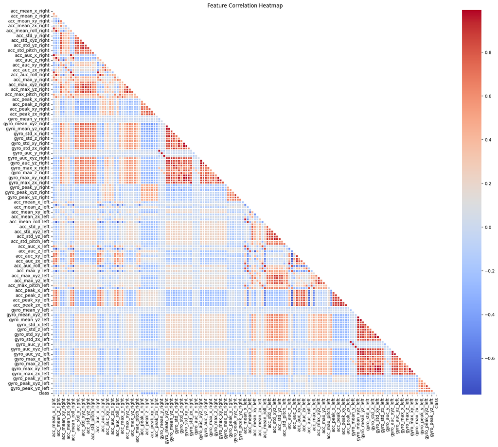

```python
# Compute correlation matrix
corr_matrix = df.corr()

# Mask upper triangle
mask = np.triu(np.ones_like(corr_matrix, dtype=bool))

# Plot the heatmap
plt.figure(figsize=(20, 16))
sns.heatmap(corr_matrix, mask=mask, cmap="coolwarm", annot=False, fmt=".2f",
            linewidths=0.1, cbar=True, square=True)

plt.xticks(rotation=90)
plt.title("Feature Correlation Heatmap")
plt.show()
```

## **3. Data Preprocessing**

### Standardizing

```python
# Standardize features
X_scaled = StandardScaler().fit_transform(X)
```

### **SMOTE**

SMOTE (Synthetic Minority Over-sampling Technique) helps handle imbalanced datasets. It generates synthetic samples for the minority class rather than duplicating existing ones. This balances class distributions, reducing bias towards the majority class.

By plotting the distribution, we can see the effect of SMOTE on class imbalances

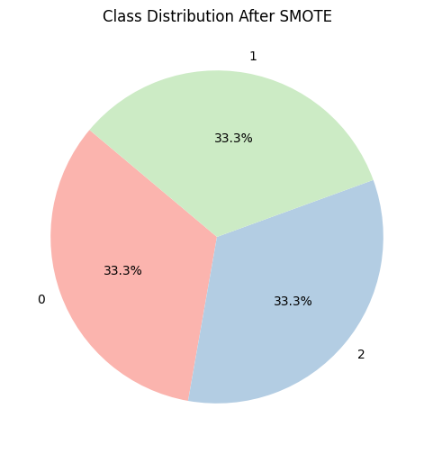

```python
# Apply SMOTE to handle class imbalance
X_resampled, y_resampled = SMOTE(random_state=42).fit_resample(X_scaled, y)

plot_class_distribution(pd.Series(y_resampled), "Class Distribution After SMOTE")
```

### **PCA**

Principal Component Analysis (PCA) is used to transform a high-dimensional dataset into a lower-dimensional form while preserving as much variance as possible.

#### Improves Efficiency

- High-dimensional datasets can be computationally expensive and difficult to process.
- PCA reduces the number of features while retaining the most critical information.
- This speeds up training times for machine learning models and reduces memory usage.

#### Removes Redundant & Correlated Features

- Many real-world datasets contain features that are highly correlated.
- PCA transforms correlated variables into a set of uncorrelated principal components, eliminating redundancy. This makes models more stable and interpretable.
- Reducing the number of dimensions helps prevent overfitting by removing irrelevant features.

```python
# Apply PCA to retain 95% variance
pca = PCA(n_components=0.95, random_state=42)
X_pca = pca.fit_transform(X_resampled)

# Display removed features
removed_features = np.argsort(np.abs(pca.components_).sum(axis=0))[X_pca.shape[1]:]
print(f"Removed features: {df.columns[removed_features].tolist()}")
```

```
Removed features: ['acc_max_xyz_left', 'gyro_auc_xyz_right', 'gyro_mean_xy_right', 'acc_std_yz_right', 'acc_max_x_left', 'gyro_auc_zx_right', 'gyro_auc_zx_left', 'gyro_std_yz_left', 'acc_mean_x_left', 'gyro_std_xy_left', 'gyro_std_yz_right', 'gyro_max_y_right', 'gyro_std_xy_right', 'gyro_std_z_left'…
```

# **Deep Dive into Classifiers**

This Notebook provides a structured breakdown of the classifiers.

For both 3 and 7 classes, we use the same approach, only that the data imported is different.

This overview includes:

- **Importing dependencies**
- **Exploring the dataset**
- **Data preprocessing steps**
- **Training and evaluating models**

## **1. Importing Dependencies**

This section imports all required libraries for data manipulation, machine learning, and evaluation.

```python
import pandas as pd
import numpy as np
import matplotlib.pyplot as plt
import seaborn as sns

from sklearn.model_selection import train_test_split, GridSearchCV
from sklearn.preprocessing import StandardScaler
from sklearn.decomposition import PCA
from imblearn.over_sampling import SMOTE

from sklearn.linear_model import LogisticRegression
from sklearn.tree import DecisionTreeClassifier
from sklearn.ensemble import RandomForestClassifier
from sklearn.neighbors import KNeighborsClassifier
from sklearn.svm import SVC
from sklearn.neural_network import MLPClassifier

from sklearn.metrics import accuracy_score, f1_score, confusion_matrix, ConfusionMatrixDisplay

from IPython.display import display
```

## **2. Dataset Exploration**

### Loading Dataset

For 7-Class

```python
# Load dataset
df = pd.read_csv("class_7_dataset.csv")
```

### Preliminary Information

Class Label Meaning:

0 = waiting/idle

1 = sharpening

2 = slicing

3 = cutting

4 = pulling

5 = reaching

6 = feeling

```python
# Display dataset info
df.info()
print(df.shape)

# Define feature and label columns
X, y = df.iloc[:, :-1], df.iloc[:, -1]
```

```
<class 'pandas.core.frame.DataFrame'>
RangeIndex: 11629 entries, 0 to 11628
Columns: 157 entries, acc_mean_x_right to class
dtypes: float64(128), int64(29)
memory usage: 13.9 MB
(11629, 157)
```

### Class Distribution

It can be observed that certain classes are quite under-represented, showing how this is an imbalanced dataset.

With 3 classes, class 0 and 1 are under-represented, and with 7 classes, class 4 and 6 are under-represented.

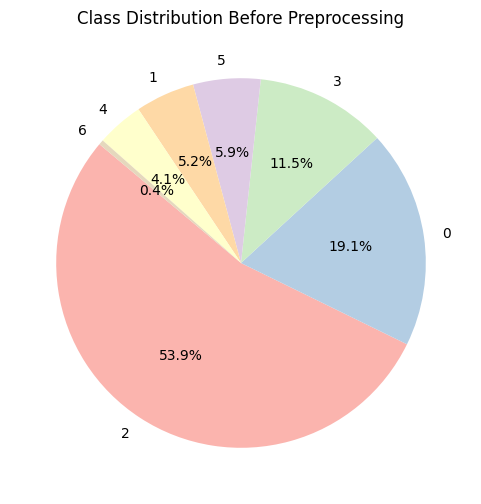

```python
# Function to plot class distribution
def plot_class_distribution(y, title):
    class_counts = y.value_counts()
    plt.figure(figsize=(6, 6))
    plt.pie(class_counts, labels=class_counts.index, autopct='%1.1f%%', startangle=140, colors=plt.cm.Pastel1.colors)
    plt.title(title)
    plt.show()

# Plot class distribution before and after SMOTE
plot_class_distribution(y, "Class Distribution Before Preprocessing")
```

### Correlation Heatmap

It can be seen that there are various features that are highly correlated with each other, making them redundant. Moreover, features can be streamlined by removing those which are not highly correlated with the class.

Note: not all feature labels are shown on the axes due to the high number of features present.

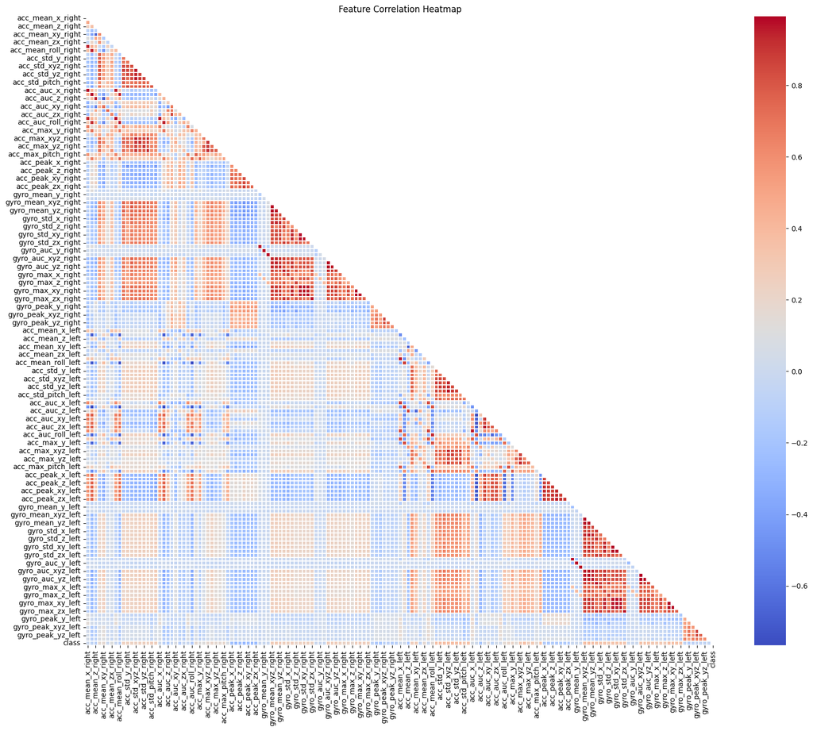

```python
# Compute correlation matrix
corr_matrix = df.corr()

# Mask upper triangle
mask = np.triu(np.ones_like(corr_matrix, dtype=bool))

# Plot the heatmap
plt.figure(figsize=(20, 16))
sns.heatmap(corr_matrix, mask=mask, cmap="coolwarm", annot=False, fmt=".2f",
            linewidths=0.1, cbar=True, square=True)

plt.xticks(rotation=90)
plt.title("Feature Correlation Heatmap")
plt.show()
```

## **3. Data Preprocessing**

### Standardizing

```python
# Standardize features
X_scaled = StandardScaler().fit_transform(X)
```

### **SMOTE**

SMOTE (Synthetic Minority Over-sampling Technique) helps handle imbalanced datasets. It generates synthetic samples for the minority class rather than duplicating existing ones. This balances class distributions, reducing bias towards the majority class.

By plotting the distribution, we can see the effect of SMOTE on class imbalances

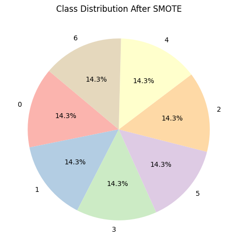

```python
# Apply SMOTE to handle class imbalance
X_resampled, y_resampled = SMOTE(random_state=42).fit_resample(X_scaled, y)

plot_class_distribution(pd.Series(y_resampled), "Class Distribution After SMOTE")
```

### **PCA**

Principal Component Analysis (PCA) is used to transform a high-dimensional dataset into a lower-dimensional form while preserving as much variance as possible.

#### Improves Efficiency

- High-dimensional datasets can be computationally expensive and difficult to process.
- PCA reduces the number of features while retaining the most critical information.
- This speeds up training times for machine learning models and reduces memory usage.

#### Removes Redundant & Correlated Features

- Many real-world datasets contain features that are highly correlated.
- PCA transforms correlated variables into a set of uncorrelated principal components, eliminating redundancy. This makes models more stable and interpretable.
- Reducing the number of dimensions helps prevent overfitting by removing irrelevant features.

```python
# Apply PCA to retain 95% variance
pca = PCA(n_components=0.95, random_state=42)
X_pca = pca.fit_transform(X_resampled)

# Display removed features
removed_features = np.argsort(np.abs(pca.components_).sum(axis=0))[X_pca.shape[1]:]
print(f"Removed features: {df.columns[removed_features].tolist()}")
```

```
Removed features: ['gyro_auc_zx_left', 'acc_std_xy_left', 'acc_peak_y_left', 'acc_auc_x_left', 'acc_std_yz_left', 'gyro_std_xy_right', 'acc_auc_yz_left', 'acc_mean_pitch_right', 'gyro_std_xyz_left', 'acc_std_x_right', 'gyro_std_yz_right', 'gyro_auc_xy_right', 'gyro_auc_yz_right', 'acc_mean_x_right',…
```

## **4. Training and Evaluating Models**

### Splitting Dataset and Defining Preliminary Functions

- Train-Test Split: Splits data into 70% training and 30% testing while preserving class distribution.
- Train Model Function: Uses GridSearchCV to find the best hyperparameters with 3-fold cross-validation.
- Hyperparameter Search Space: Defines tuning parameters for multiple machine learning models.
- Confusion Matrix Function: Generates and visualizes confusion matrices to assess classification performance.
- Model Metrics List: Stores evaluation results for comparison across different models.

```python
# Split dataset
X_train, X_test, y_train, y_test = train_test_split(X_pca, y_resampled, test_size=0.3, stratify=y_resampled,
                                                    random_state=42)


# Function to perform GridSearchCV
def train_model(model, param_grid, X_train, y_train):
    grid_search = GridSearchCV(model, param_grid, cv=3, scoring='accuracy', n_jobs=-1)
    grid_search.fit(X_train, y_train)
    return grid_search.best_estimator_


# Hyperparameter search space
param_grids = {
    "Logistic Regression": {"C": [0.01, 0.1, 1, 10], "max_iter": [500, 1000]},
    "Decision Tree": {"max_depth": [5, 10, 20]},
    "Random Forest": {"n_estimators": [50, 100, 200], "max_depth": [10, 20]},
    "K-Nearest Neighbors": {"n_neighbors": [3, 5, 7]},
    "Support Vector Machine": {"C": [0.1, 1, 10], "kernel": ["linear", "rbf"]},
    "Neural Network": {"hidden_layer_sizes": [(50,), (100,)], "max_iter": [1000, 1500]},
}


# Function to plot confusion matrix
def plot_confusion_matrix(test, pred, name):
    cm = confusion_matrix(test, pred)
    disp = ConfusionMatrixDisplay(confusion_matrix=cm, display_labels=np.unique(y_test))
    disp.plot(cmap="Blues", values_format="d")
    plt.title(f"Confusion Matrix - {name}")
    plt.show()


# List to store model metrics
model_stats = []
```

### Logistic Regression

```
Training Logistic Regression...
```

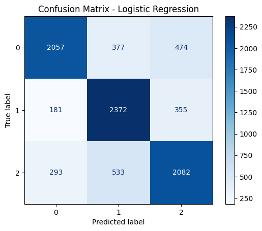

```
Accuracy: 0.7463, F1 Score: 0.7461
```

```python
# Train and evaluate Logistic Regression
print("\nTraining Logistic Regression...")
log_reg = train_model(LogisticRegression(solver='lbfgs'), param_grids["Logistic Regression"], X_train, y_train)
y_pred = log_reg.predict(X_test)
accuracy = accuracy_score(y_test, y_pred)
f1 = f1_score(y_test, y_pred, average='weighted')
plot_confusion_matrix(y_test, y_pred, "Logistic Regression")
model_stats.append({"Model": "Logistic Regression", "Accuracy": accuracy, "F1 Score": f1})
print(f"Accuracy: {accuracy:.4f}, F1 Score: {f1:.4f}")
```

### Decision Tree

```
Training Decision Tree...
```

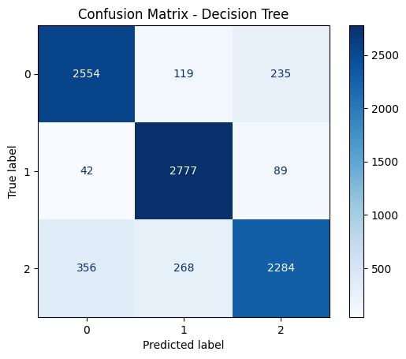

```
Accuracy: 0.8729, F1 Score: 0.8715
```

```python
# Train and evaluate Decision Tree
print("\nTraining Decision Tree...")
decision_tree = train_model(DecisionTreeClassifier(), param_grids["Decision Tree"], X_train, y_train)
y_pred = decision_tree.predict(X_test)
accuracy = accuracy_score(y_test, y_pred)
f1 = f1_score(y_test, y_pred, average='weighted')
plot_confusion_matrix(y_test, y_pred, "Decision Tree")
model_stats.append({"Model": "Decision Tree", "Accuracy": accuracy, "F1 Score": f1})
print(f"Accuracy: {accuracy:.4f}, F1 Score: {f1:.4f}")
```

### Random Forest

```
Training Random Forest...
```

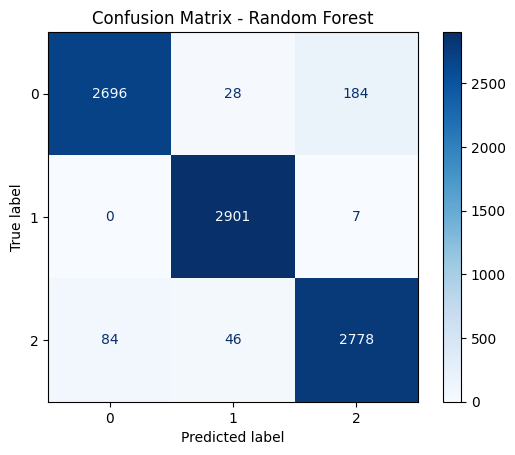

```
Accuracy: 0.9600, F1 Score: 0.9599
```

```python
# Train and evaluate Random Forest
print("\nTraining Random Forest...")
random_forest = train_model(RandomForestClassifier(), param_grids["Random Forest"], X_train, y_train)
y_pred = random_forest.predict(X_test)
accuracy = accuracy_score(y_test, y_pred)
f1 = f1_score(y_test, y_pred, average='weighted')
plot_confusion_matrix(y_test, y_pred, "Random Forest")
model_stats.append({"Model": "Random Forest", "Accuracy": accuracy, "F1 Score": f1})
print(f"Accuracy: {accuracy:.4f}, F1 Score: {f1:.4f}")
```

### K-Nearest Neighbors

```
Training K-Nearest Neighbors...
```

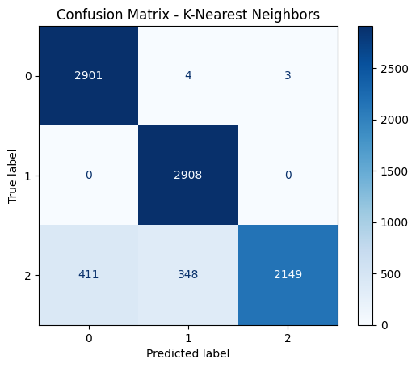

```
Accuracy: 0.9122, F1 Score: 0.9084
```

```python
print("\nTraining K-Nearest Neighbors...")
knn = train_model(KNeighborsClassifier(), param_grids["K-Nearest Neighbors"], X_train, y_train)
y_pred = knn.predict(X_test)
accuracy = accuracy_score(y_test, y_pred)
f1 = f1_score(y_test, y_pred, average='weighted')
plot_confusion_matrix(y_test, y_pred, "K-Nearest Neighbors")
model_stats.append({"Model": "K-Nearest Neighbors", "Accuracy": accuracy, "F1 Score": f1})
print(f"Accuracy: {accuracy:.4f}, F1 Score: {f1:.4f}")
```

### Support Vector Machine

```
Training Support Vector Machine...
```

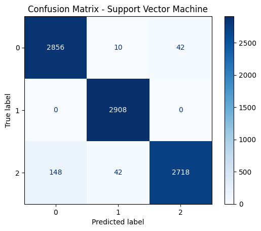

```
Accuracy: 0.9723, F1 Score: 0.9721
```

```python
# Train and evaluate Support Vector Machine
print("\nTraining Support Vector Machine...")
svm = train_model(SVC(), param_grids["Support Vector Machine"], X_train, y_train)
y_pred = svm.predict(X_test)
accuracy = accuracy_score(y_test, y_pred)
f1 = f1_score(y_test, y_pred, average='weighted')
plot_confusion_matrix(y_test, y_pred, "Support Vector Machine")
model_stats.append({"Model": "Support Vector Machine", "Accuracy": accuracy, "F1 Score": f1})
print(f"Accuracy: {accuracy:.4f}, F1 Score: {f1:.4f}")
```

### Neural Network

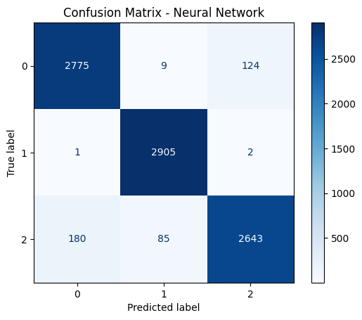

```
Accuracy: 0.9540, F1 Score: 0.9537
```

```python
mlp = train_model(MLPClassifier(), param_grids["Neural Network"], X_train, y_train)
y_pred = mlp.predict(X_test)
accuracy = accuracy_score(y_test, y_pred)
f1 = f1_score(y_test, y_pred, average='weighted')
plot_confusion_matrix(y_test, y_pred, "Neural Network")
model_stats.append({"Model": "Neural Network", "Accuracy": accuracy, "F1 Score": f1})
print(f"Accuracy: {accuracy:.4f}, F1 Score: {f1:.4f}")
```

## **4. Training and Evaluating Models**

### Splitting Dataset and Defining Preliminary Functions

- Train-Test Split: Splits data into 70% training and 30% testing while preserving class distribution.
- Train Model Function: Uses GridSearchCV to find the best hyperparameters with 3-fold cross-validation.
- Hyperparameter Search Space: Defines tuning parameters for multiple machine learning models.
- Confusion Matrix Function: Generates and visualizes confusion matrices to assess classification performance.
- Model Metrics List: Stores evaluation results for comparison across different models.

```python
# Split dataset
X_train, X_test, y_train, y_test = train_test_split(X_pca, y_resampled, test_size=0.3, stratify=y_resampled,
                                                    random_state=42)


# Function to perform GridSearchCV
def train_model(model, param_grid, X_train, y_train):
    grid_search = GridSearchCV(model, param_grid, cv=3, scoring='accuracy', n_jobs=-1)
    grid_search.fit(X_train, y_train)
    return grid_search.best_estimator_


# Hyperparameter search space
param_grids = {
    "Logistic Regression": {"C": [0.01, 0.1, 1, 10], "max_iter": [500, 1000]},
    "Decision Tree": {"max_depth": [5, 10, 20]},
    "Random Forest": {"n_estimators": [50, 100, 200], "max_depth": [10, 20]},
    "K-Nearest Neighbors": {"n_neighbors": [3, 5, 7]},
    "Support Vector Machine": {"C": [0.1, 1, 10], "kernel": ["linear", "rbf"]},
    "Neural Network": {"hidden_layer_sizes": [(50,), (100,)], "max_iter": [1000, 1500]},
}


# Function to plot confusion matrix
def plot_confusion_matrix(test, pred, name):
    cm = confusion_matrix(test, pred)
    disp = ConfusionMatrixDisplay(confusion_matrix=cm, display_labels=np.unique(y_test))
    disp.plot(cmap="Blues", values_format="d")
    plt.title(f"Confusion Matrix - {name}")
    plt.show()


# List to store model metrics
model_stats = []
```

### Logistic Regression

```
Training Logistic Regression...
```

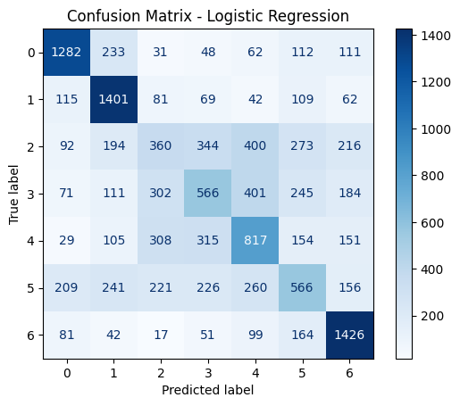

```
Accuracy: 0.4879, F1 Score: 0.4735
```

```python
# Train and evaluate Logistic Regression
print("\nTraining Logistic Regression...")
log_reg = train_model(LogisticRegression(solver='lbfgs'), param_grids["Logistic Regression"], X_train, y_train)
y_pred = log_reg.predict(X_test)
accuracy = accuracy_score(y_test, y_pred)
f1 = f1_score(y_test, y_pred, average='weighted')
plot_confusion_matrix(y_test, y_pred, "Logistic Regression")
model_stats.append({"Model": "Logistic Regression", "Accuracy": accuracy, "F1 Score": f1})
print(f"Accuracy: {accuracy:.4f}, F1 Score: {f1:.4f}")
```

### Decision Tree

```
Training Decision Tree...
```

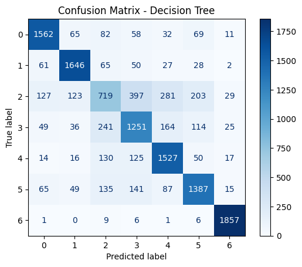

```
Accuracy: 0.7563, F1 Score: 0.7501
```

```python
# Train and evaluate Decision Tree
print("\nTraining Decision Tree...")
decision_tree = train_model(DecisionTreeClassifier(), param_grids["Decision Tree"], X_train, y_train)
y_pred = decision_tree.predict(X_test)
accuracy = accuracy_score(y_test, y_pred)
f1 = f1_score(y_test, y_pred, average='weighted')
plot_confusion_matrix(y_test, y_pred, "Decision Tree")
model_stats.append({"Model": "Decision Tree", "Accuracy": accuracy, "F1 Score": f1})
print(f"Accuracy: {accuracy:.4f}, F1 Score: {f1:.4f}")
```

### Random Forest

```
Training Random Forest...
```

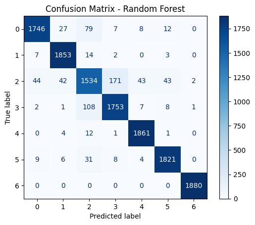

```
Accuracy: 0.9463, F1 Score: 0.9458
```

```python
# Train and evaluate Random Forest
print("\nTraining Random Forest...")
random_forest = train_model(RandomForestClassifier(), param_grids["Random Forest"], X_train, y_train)
y_pred = random_forest.predict(X_test)
accuracy = accuracy_score(y_test, y_pred)
f1 = f1_score(y_test, y_pred, average='weighted')
plot_confusion_matrix(y_test, y_pred, "Random Forest")
model_stats.append({"Model": "Random Forest", "Accuracy": accuracy, "F1 Score": f1})
print(f"Accuracy: {accuracy:.4f}, F1 Score: {f1:.4f}")
```

### K-Nearest Neighbors

```
Training K-Nearest Neighbors...
```

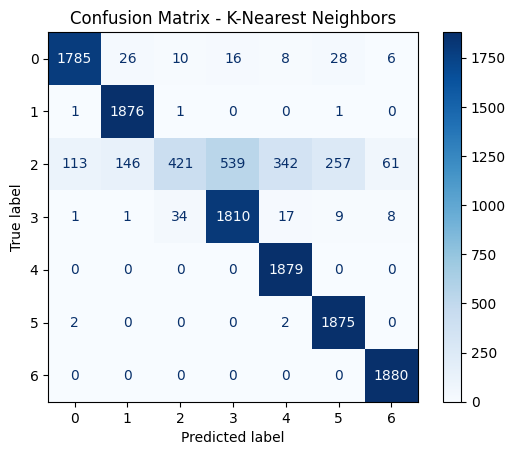

```
Accuracy: 0.8762, F1 Score: 0.8469
```

```python
print("\nTraining K-Nearest Neighbors...")
knn = train_model(KNeighborsClassifier(), param_grids["K-Nearest Neighbors"], X_train, y_train)
y_pred = knn.predict(X_test)
accuracy = accuracy_score(y_test, y_pred)
f1 = f1_score(y_test, y_pred, average='weighted')
plot_confusion_matrix(y_test, y_pred, "K-Nearest Neighbors")
model_stats.append({"Model": "K-Nearest Neighbors", "Accuracy": accuracy, "F1 Score": f1})
print(f"Accuracy: {accuracy:.4f}, F1 Score: {f1:.4f}")
```

### Support Vector Machine

```
Training Support Vector Machine...
```

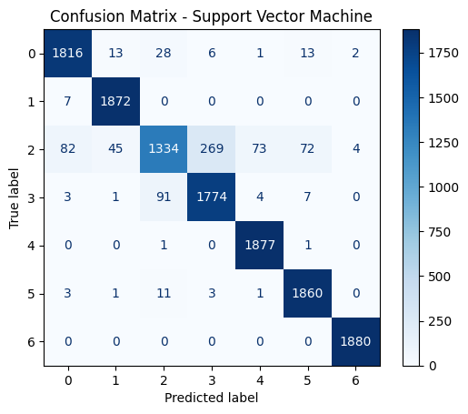

```
Accuracy: 0.9436, F1 Score: 0.9413
```

```python
# Train and evaluate Support Vector Machine
print("\nTraining Support Vector Machine...")
svm = train_model(SVC(), param_grids["Support Vector Machine"], X_train, y_train)
y_pred = svm.predict(X_test)
accuracy = accuracy_score(y_test, y_pred)
f1 = f1_score(y_test, y_pred, average='weighted')
plot_confusion_matrix(y_test, y_pred, "Support Vector Machine")
model_stats.append({"Model": "Support Vector Machine", "Accuracy": accuracy, "F1 Score": f1})
print(f"Accuracy: {accuracy:.4f}, F1 Score: {f1:.4f}")
```

### Neural Network

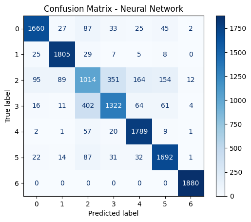

```
Accuracy: 0.8485, F1 Score: 0.8450
```

```python
mlp = train_model(MLPClassifier(), param_grids["Neural Network"], X_train, y_train)
y_pred = mlp.predict(X_test)
accuracy = accuracy_score(y_test, y_pred)
f1 = f1_score(y_test, y_pred, average='weighted')
plot_confusion_matrix(y_test, y_pred, "Neural Network")
model_stats.append({"Model": "Neural Network", "Accuracy": accuracy, "F1 Score": f1})
print(f"Accuracy: {accuracy:.4f}, F1 Score: {f1:.4f}")
```

### Overall Evaluation

Displays the Accuracy and F1 Score for each model.

From here, we find that the SVM, Random Forest, and NN are amongst the best classifiers.

```python
# Create and display model statistics dataframe
model_stats_df = pd.DataFrame(model_stats)
display(model_stats_df)
```

|  | Model | Accuracy | F1 Score |
| --- | --- | --- | --- |
| 0 | Logistic Regression | 0.746332 | 0.746124 |
| 1 | Decision Tree | 0.872879 | 0.871500 |
| 2 | Random Forest | 0.959995 | 0.959857 |
| 3 | K-Nearest Neighbors | 0.912196 | 0.908379 |
| 4 | Support Vector Machine | 0.972260 | 0.972126 |
| 5 | Neural Network | 0.954035 | 0.953719 |

### Overall Evaluation

Displays the Accuracy and F1 Score for each model.

```python
# Create and display model statistics dataframe
model_stats_df = pd.DataFrame(model_stats)
display(model_stats_df)
```

|  | Model | Accuracy | F1 Score |
| --- | --- | --- | --- |
| 0 | Logistic Regression | 0.487875 | 0.473469 |
| 1 | Decision Tree | 0.756290 | 0.750057 |
| 2 | Random Forest | 0.946256 | 0.945794 |
| 3 | K-Nearest Neighbors | 0.876169 | 0.846926 |
| 4 | Support Vector Machine | 0.943596 | 0.941284 |
| 5 | Neural Network | 0.848499 | 0.845037 |

#### 3-Activity No Preprocessing:

| Model | Accuracy | F1 Score |
| --- | --- | --- |
| Logistic Regression | 0.902 | 0.891 |
| Decision Tree | 0.906 | 0.903 |
| Random Forest | 0.921 | 0.913 |
| K-Nearest Neighbors | 0.912 | 0.906 |
| Support Vector Machine | 0.916 | 0.912 |
| Neural Network | 0.899 | 0.894 |

#### 3-Activity No PCA:

| Model | Accuracy | F1 Score |
| --- | --- | --- |
| Logistic Regression | 0.808 | 0.808 |
| Decision Tree | 0.899 | 0.898 |
| Random Forest | 0.968 | 0.968 |
| K-Nearest Neighbors | 0.895 | 0.889 |
| Support Vector Machine | 0.981 | 0.981 |
| Neural Network | 0.974 | 0.974 |

#### 3-Activity Full Preprocessing:

| Model | Accuracy | F1 Score |
| --- | --- | --- |
| Logistic Regression | 0.746 | 0.746 |
| Decision Tree | 0.873 | 0.872 |
| Random Forest | 0.960 | 0.960 |
| K-Nearest Neighbors | 0.912 | 0.908 |
| Support Vector Machine | 0.972 | 0.972 |
| Neural Network | 0.954 | 0.954 |

#### 7-Activity No Preprocessing:

| Model | Accuracy | F1 Score |
| --- | --- | --- |
| Logistic Regression | 0.684 | 0.605 |
| Decision Tree | 0.684 | 0.602 |
| Random Forest | 0.709 | 0.626 |
| K-Nearest Neighbors | 0.681 | 0.615 |
| Support Vector Machine | 0.702 | 0.617 |
| Neural Network | 0.580 | 0.586 |

#### 7-Activity No PCA:

| Model | Accuracy | F1 Score |
| --- | --- | --- |
| Logistic Regression | 0.633 | 0.624 |
| Decision Tree | 0.781 | 0.779 |
| Random Forest | 0.949 | 0.949 |
| K-Nearest Neighbors | 0.873 | 0.840 |
| Support Vector Machine | 0.956 | 0.955 |
| Neural Network | 0.907 | 0.905 |

#### 7-Activity Full Preprocessing:

| Model | Accuracy | F1 Score |
| --- | --- | --- |
| Logistic Regression | 0.488 | 0.473 |
| Decision Tree | 0.756 | 0.750 |
| Random Forest | 0.946 | 0.946 |
| K-Nearest Neighbors | 0.876 | 0.847 |
| Support Vector Machine | 0.944 | 0.941 |
| Neural Network | 0.848 | 0.845 |

## Using Raw Data and Deep Learning Models

[figure not shown]

Data Preparation Workflow

### Data Segmentation

The dataset was segmented using a sliding window technique with a fixed window size of 30 (by observation, roughly the number of samples per second) and a stride of 15. This method increased the number of training examples without altering the underlying data distribution. Each window captures a local temporal pattern, and the overlap ensures smooth transitions between segments.

### Dataset Handling

The raw dataset consisted of synchronised accelerometer and gyroscope signals (by timestamp) collected from both hands. Therefore, each worker would have four data files (acceleration right, acceleration left, gyro right, gyro left), which were later merged on timestamps to the closest signal within a certain tolerance. Each signal channel was standardised using StandardScaler, and windowed sequences were reshaped to a uniform shape of (samples, time_steps, features). The dataset was split into training and test sets using an 80:20 ratio, which was used across all models for fair comparison.

### Implementation Details

All models were implemented using TensorFlow 2.0 and Keras. Training was performed using the Adam optimiser with an initial learning rate of 0.001 and the ‘categorical_crossentropy’ loss function. The batch size was set to 64, and each model was trained for 100 epochs. Different tolerances were considered, with a 0.01 and 0.02 tolerance being used.

#### CNN with Attention

This model modifies the baseline by incorporating a self-attention mechanism immediately after the LSTM output. Instead of feeding the entire output sequence directly into dense layers, the model computes a learned weighted sum over the LSTM outputs using a trainable attention layer. The attention vector is then concatenated with the global LSTM output and passed through a dense layer before classification.

#### CNN with Cross Attention

As an exploration of the bilateral nature of the data (left and right hand signals), this architecture introduces a cross-attention mechanism between two separate CNN-LSTM pipelines. Each input branch processes data from one hand using its own convolutional and recurrent layers. After the LSTM stage, the two streams interact via a cross-attention mechanism, where each stream attends to the other’s output sequence. This enables the model to learn contextual relationships and interdependencies between the two hands. The attended outputs are concatenated and passed through shared dense layers to produce the final prediction.

#### CNN without Max Pooling

To assess the effect of temporal resolution loss due to pooling, this model removes all max-pooling layers from the cross-attention model and uses global pooling.

| Model | Accuracy (Tolerance = 0.01) | Accuracy (Tolerance = 0.02) |
| --- | --- | --- |
| CNN-LSTM Basic | 0.795 | 0.726 |
| CNN-LSTM (Attention) | 0.765 | 0.777 |
| CNN-LSTM (Cross-Attention) | 0.810 | 0.739 |
| CNN-LSTM (No Max Pooling) | 0.846 | 0.807 |

| Model | Accuracy (Tolerance = 0.01) | Accuracy (Tolerance = 0.02) |
| --- | --- | --- |
| CNN-LSTM Basic | 0.944 | 0.924 |
| CNN-LSTM (Attention) | 0.922 | 0.925 |
| CNN-LSTM (Cross-Attention) | 0.949 | 0.941 |
| CNN-LSTM (No Max Pooling) | 0.955 | 0.951 |

## Download

GitHub Link: **[Models and Raw Data](https://github.com/DigitalInnovationLab/mpp_dataset/tree/main/raw-data)**